# examples_0529

Three people are buying fruit, and there are five grocery stores. Each person has a shopping list dictating how many pounds of each fruit to buy. Each store has different unit costs of fruit.

In order to consider the **total** cost for each person at each store, we can use [matrix multiplication](https://en.wikipedia.org/wiki/Matrix_multiplication). In order to help visualize matrix multiplication, the shopping lists are shown as a matrix on the bottom-left, the unit prices as a matrix on top-right, and the resulting matrix of totals in the bottom-right.

A peculiarity of matrix multiplication requires the **columns** of the first matrix to "match" the **rows** of the second matrix. In this case, notice the various fruits correspond to columns in the first matrix (bottom-left) and rows in the second matrix (top-right). This visualization is an attempt to make this seem more natural.

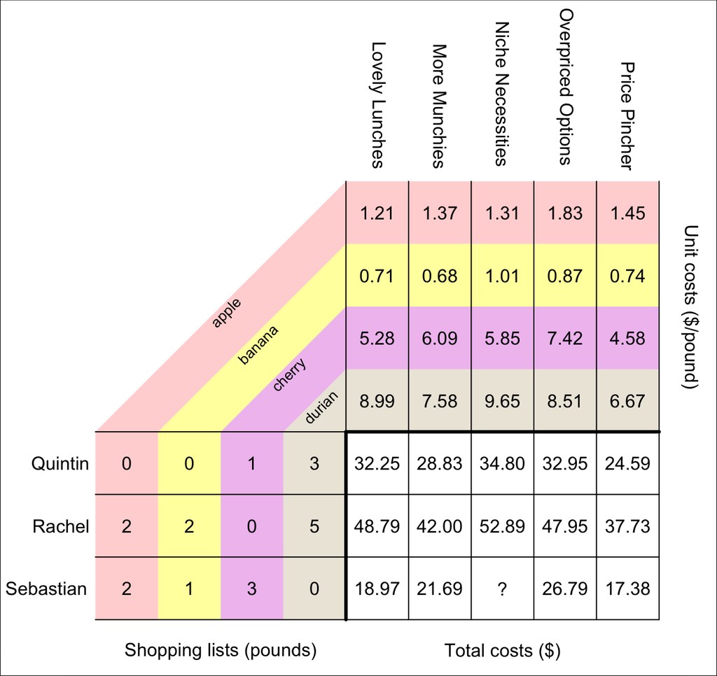

What is the total cost of Sebastian shopping at Niche Necessities?

Sebastian wishes to buy 2 lb of apple, 1 lb of banana, 3 lb of cherry, and 0 lb of durian. At Niche Necessities, the unit price of apple is $1.31/lb, the unit price of banana is $1.01/lb, the unit price of cherry is $5.85/lb, and the unit price of durian is $9.65/lb.

To find the total cost of Sebastian's shopping trip, multiply each quantity by its corresponding unit price and then add up all those products.

$$(2\cdot1.31)~+~(1\cdot1.01)~+~(3\cdot5.85)~+~(0\cdot9.65)$$
$$2.62~+~1.01~+~17.55~+~0$$
$$21.18$$

So, the total cost of Sebastian shopping at Niche Necessities is $21.18.

In standard math notation, the matrix multiplication would be shown as:

$$\begin{bmatrix}
0 & 0 & 1 & 3\\
2 & 2 & 0 & 5\\
2 & 1 & 3 & 0
\end{bmatrix} \cdot \begin{bmatrix}
1.21 & 1.37 & 1.31 & 1.83 & 1.45\\
0.71 & 0.68 & 1.01 & 0.87 & 0.74\\
5.28 & 6.09 & 5.85 & 7.42 & 4.58\\
8.99 & 7.58 & 9.65 & 8.51 & 6.67
\end{bmatrix} ~=~ \begin{bmatrix}
32.25 & 28.83 & 34.8 & 32.95 & 24.59\\
48.79 & 42 & 52.89 & 47.95 & 37.73\\
18.97 & 21.69 & 21.18 & 26.79 & 17.38
\end{bmatrix}$$

Three people are buying fruit, and there are five grocery stores. Each person has a shopping list dictating how many pounds of each fruit to buy. Each store has different unit costs of fruit.

In order to consider the **total** cost for each person at each store, we can use [matrix multiplication](https://en.wikipedia.org/wiki/Matrix_multiplication). In order to help visualize matrix multiplication, the shopping lists are shown as a matrix on the bottom-left, the unit prices as a matrix on top-right, and the resulting matrix of totals in the bottom-right.

A peculiarity of matrix multiplication requires the **columns** of the first matrix to "match" the **rows** of the second matrix. In this case, notice the various fruits correspond to columns in the first matrix (bottom-left) and rows in the second matrix (top-right). This visualization is an attempt to make this seem more natural.

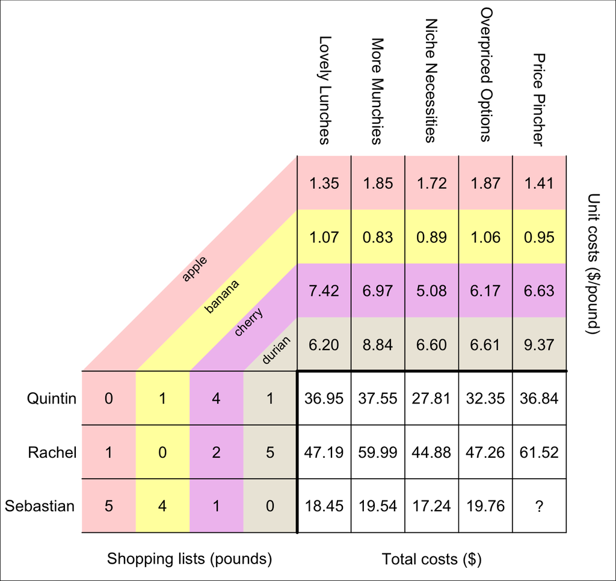

What is the total cost of Sebastian shopping at Price Pincher?

Sebastian wishes to buy 5 lb of apple, 4 lb of banana, 1 lb of cherry, and 0 lb of durian. At Price Pincher, the unit price of apple is $1.41/lb, the unit price of banana is $0.95/lb, the unit price of cherry is $6.63/lb, and the unit price of durian is $9.37/lb.

To find the total cost of Sebastian's shopping trip, multiply each quantity by its corresponding unit price and then add up all those products.

$$(5\cdot1.41)~+~(4\cdot0.95)~+~(1\cdot6.63)~+~(0\cdot9.37)$$
$$7.05~+~3.8~+~6.63~+~0$$
$$17.48$$

So, the total cost of Sebastian shopping at Price Pincher is $17.48.

In standard math notation, the matrix multiplication would be shown as:

$$\begin{bmatrix}
0 & 1 & 4 & 1\\
1 & 0 & 2 & 5\\
5 & 4 & 1 & 0
\end{bmatrix} \cdot \begin{bmatrix}
1.35 & 1.85 & 1.72 & 1.87 & 1.41\\
1.07 & 0.83 & 0.89 & 1.06 & 0.95\\
7.42 & 6.97 & 5.08 & 6.17 & 6.63\\
6.2 & 8.84 & 6.6 & 6.61 & 9.37
\end{bmatrix} ~=~ \begin{bmatrix}
36.95 & 37.55 & 27.81 & 32.35 & 36.84\\
47.19 & 59.99 & 44.88 & 47.26 & 61.52\\
18.45 & 19.54 & 17.24 & 19.76 & 17.48
\end{bmatrix}$$

Three people are buying fruit, and there are five grocery stores. Each person has a shopping list dictating how many pounds of each fruit to buy. Each store has different unit costs of fruit.

In order to consider the **total** cost for each person at each store, we can use [matrix multiplication](https://en.wikipedia.org/wiki/Matrix_multiplication). In order to help visualize matrix multiplication, the shopping lists are shown as a matrix on the bottom-left, the unit prices as a matrix on top-right, and the resulting matrix of totals in the bottom-right.

A peculiarity of matrix multiplication requires the **columns** of the first matrix to "match" the **rows** of the second matrix. In this case, notice the various fruits correspond to columns in the first matrix (bottom-left) and rows in the second matrix (top-right). This visualization is an attempt to make this seem more natural.

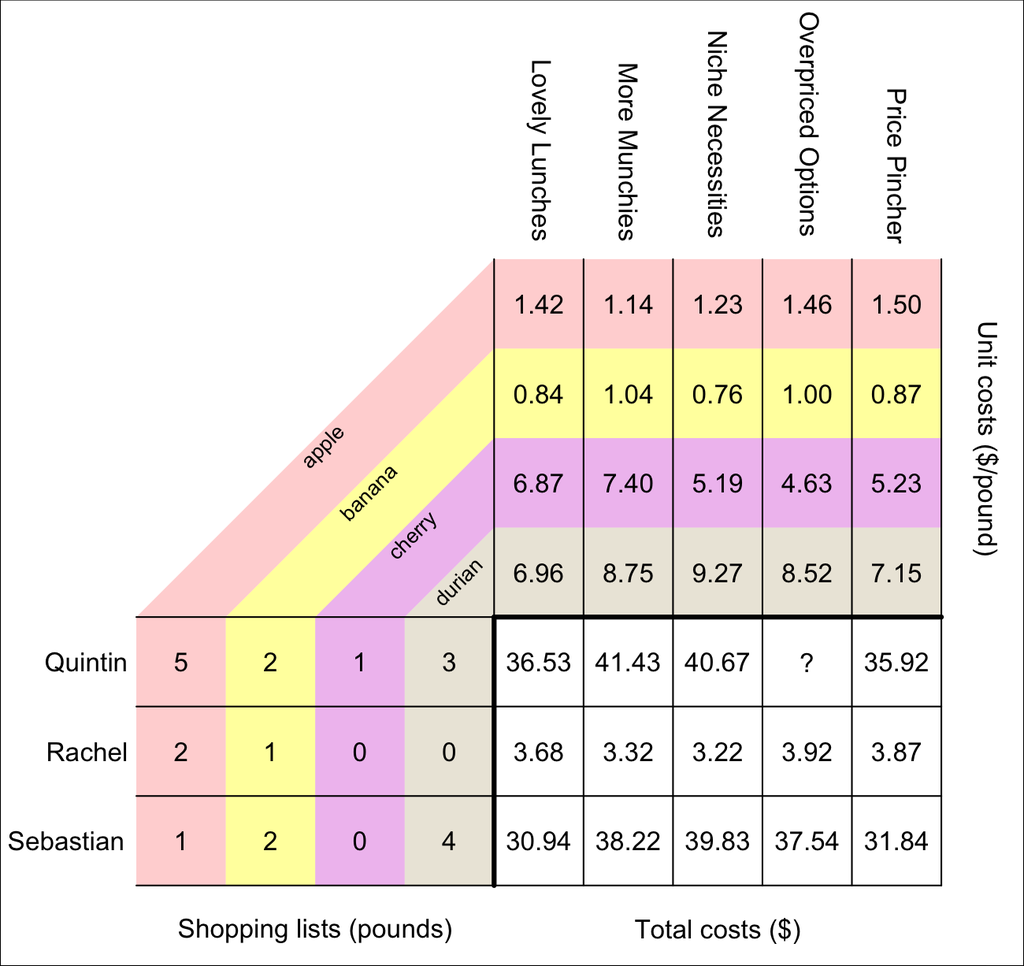

What is the total cost of Quintin shopping at Overpriced Options?

Quintin wishes to buy 5 lb of apple, 2 lb of banana, 1 lb of cherry, and 3 lb of durian. At Overpriced Options, the unit price of apple is $1.46/lb, the unit price of banana is $1.00/lb, the unit price of cherry is $4.63/lb, and the unit price of durian is $8.52/lb.

To find the total cost of Quintin's shopping trip, multiply each quantity by its corresponding unit price and then add up all those products.

$$(5\cdot1.46)~+~(2\cdot1)~+~(1\cdot4.63)~+~(3\cdot8.52)$$
$$7.3~+~2~+~4.63~+~25.56$$
$$39.49$$

So, the total cost of Quintin shopping at Overpriced Options is $39.49.

In standard math notation, the matrix multiplication would be shown as:

$$\begin{bmatrix}
5 & 2 & 1 & 3\\
2 & 1 & 0 & 0\\
1 & 2 & 0 & 4
\end{bmatrix} \cdot \begin{bmatrix}
1.42 & 1.14 & 1.23 & 1.46 & 1.5\\
0.84 & 1.04 & 0.76 & 1 & 0.87\\
6.87 & 7.4 & 5.19 & 4.63 & 5.23\\
6.96 & 8.75 & 9.27 & 8.52 & 7.15
\end{bmatrix} ~=~ \begin{bmatrix}
36.53 & 41.43 & 40.67 & 39.49 & 35.92\\
3.68 & 3.32 & 3.22 & 3.92 & 3.87\\
30.94 & 38.22 & 39.83 & 37.54 & 31.84
\end{bmatrix}$$

Three people are buying fruit, and there are five grocery stores. Each person has a shopping list dictating how many pounds of each fruit to buy. Each store has different unit costs of fruit.

In order to consider the **total** cost for each person at each store, we can use [matrix multiplication](https://en.wikipedia.org/wiki/Matrix_multiplication). In order to help visualize matrix multiplication, the shopping lists are shown as a matrix on the bottom-left, the unit prices as a matrix on top-right, and the resulting matrix of totals in the bottom-right.

A peculiarity of matrix multiplication requires the **columns** of the first matrix to "match" the **rows** of the second matrix. In this case, notice the various fruits correspond to columns in the first matrix (bottom-left) and rows in the second matrix (top-right). This visualization is an attempt to make this seem more natural.

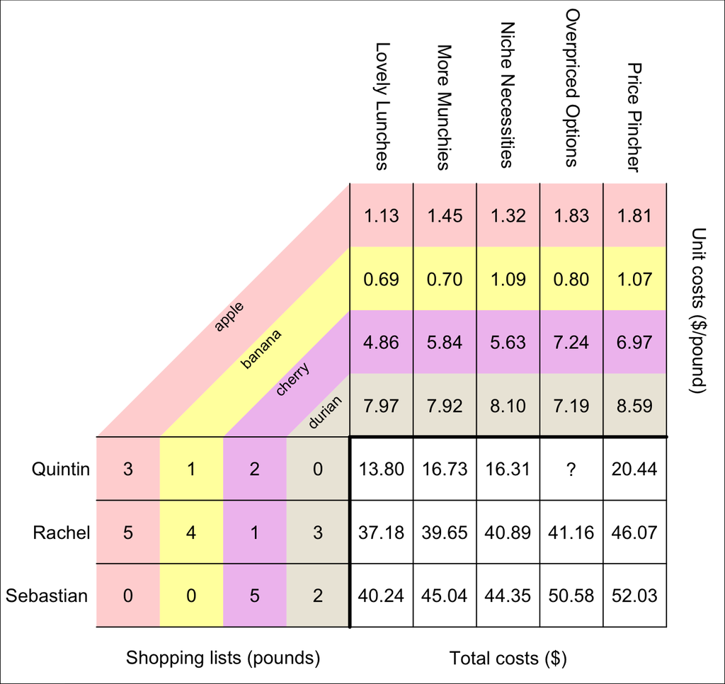

What is the total cost of Quintin shopping at Overpriced Options?

Quintin wishes to buy 3 lb of apple, 1 lb of banana, 2 lb of cherry, and 0 lb of durian. At Overpriced Options, the unit price of apple is $1.83/lb, the unit price of banana is $0.80/lb, the unit price of cherry is $7.24/lb, and the unit price of durian is $7.19/lb.

To find the total cost of Quintin's shopping trip, multiply each quantity by its corresponding unit price and then add up all those products.

$$(3\cdot1.83)~+~(1\cdot0.8)~+~(2\cdot7.24)~+~(0\cdot7.19)$$
$$5.49~+~0.8~+~14.48~+~0$$
$$20.77$$

So, the total cost of Quintin shopping at Overpriced Options is $20.77.

In standard math notation, the matrix multiplication would be shown as:

$$\begin{bmatrix}
3 & 1 & 2 & 0\\
5 & 4 & 1 & 3\\
0 & 0 & 5 & 2
\end{bmatrix} \cdot \begin{bmatrix}
1.13 & 1.45 & 1.32 & 1.83 & 1.81\\
0.69 & 0.7 & 1.09 & 0.8 & 1.07\\
4.86 & 5.84 & 5.63 & 7.24 & 6.97\\
7.97 & 7.92 & 8.1 & 7.19 & 8.59
\end{bmatrix} ~=~ \begin{bmatrix}
13.8 & 16.73 & 16.31 & 20.77 & 20.44\\
37.18 & 39.65 & 40.89 & 41.16 & 46.07\\
40.24 & 45.04 & 44.35 & 50.58 & 52.03
\end{bmatrix}$$

Three people are buying fruit, and there are five grocery stores. Each person has a shopping list dictating how many pounds of each fruit to buy. Each store has different unit costs of fruit.

In order to consider the **total** cost for each person at each store, we can use [matrix multiplication](https://en.wikipedia.org/wiki/Matrix_multiplication). In order to help visualize matrix multiplication, the shopping lists are shown as a matrix on the bottom-left, the unit prices as a matrix on top-right, and the resulting matrix of totals in the bottom-right.

A peculiarity of matrix multiplication requires the **columns** of the first matrix to "match" the **rows** of the second matrix. In this case, notice the various fruits correspond to columns in the first matrix (bottom-left) and rows in the second matrix (top-right). This visualization is an attempt to make this seem more natural.

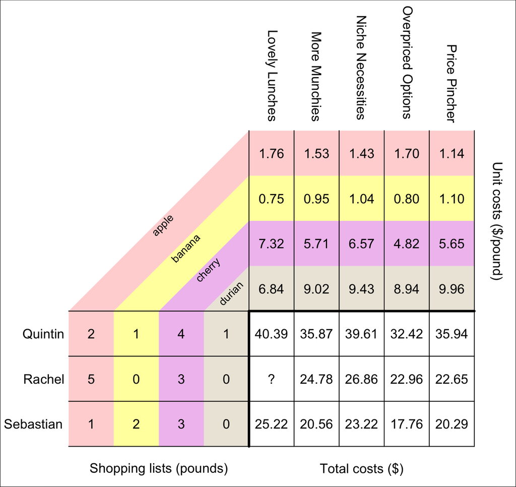

What is the total cost of Rachel shopping at Lovely Lunches?

Rachel wishes to buy 5 lb of apple, 0 lb of banana, 3 lb of cherry, and 0 lb of durian. At Lovely Lunches, the unit price of apple is $1.76/lb, the unit price of banana is $0.75/lb, the unit price of cherry is $7.32/lb, and the unit price of durian is $6.84/lb.

To find the total cost of Rachel's shopping trip, multiply each quantity by its corresponding unit price and then add up all those products.

$$(5\cdot1.76)~+~(0\cdot0.75)~+~(3\cdot7.32)~+~(0\cdot6.84)$$
$$8.8~+~0~+~21.96~+~0$$
$$30.76$$

So, the total cost of Rachel shopping at Lovely Lunches is $30.76.

In standard math notation, the matrix multiplication would be shown as:

$$\begin{bmatrix}
2 & 1 & 4 & 1\\
5 & 0 & 3 & 0\\
1 & 2 & 3 & 0
\end{bmatrix} \cdot \begin{bmatrix}
1.76 & 1.53 & 1.43 & 1.7 & 1.14\\
0.75 & 0.95 & 1.04 & 0.8 & 1.1\\
7.32 & 5.71 & 6.57 & 4.82 & 5.65\\
6.84 & 9.02 & 9.43 & 8.94 & 9.96
\end{bmatrix} ~=~ \begin{bmatrix}
40.39 & 35.87 & 39.61 & 32.42 & 35.94\\
30.76 & 24.78 & 26.86 & 22.96 & 22.65\\
25.22 & 20.56 & 23.22 & 17.76 & 20.29
\end{bmatrix}$$

Three people are buying fruit, and there are five grocery stores. Each person has a shopping list dictating how many pounds of each fruit to buy. Each store has different unit costs of fruit.

In order to consider the **total** cost for each person at each store, we can use [matrix multiplication](https://en.wikipedia.org/wiki/Matrix_multiplication). In order to help visualize matrix multiplication, the shopping lists are shown as a matrix on the bottom-left, the unit prices as a matrix on top-right, and the resulting matrix of totals in the bottom-right.

A peculiarity of matrix multiplication requires the **columns** of the first matrix to "match" the **rows** of the second matrix. In this case, notice the various fruits correspond to columns in the first matrix (bottom-left) and rows in the second matrix (top-right). This visualization is an attempt to make this seem more natural.

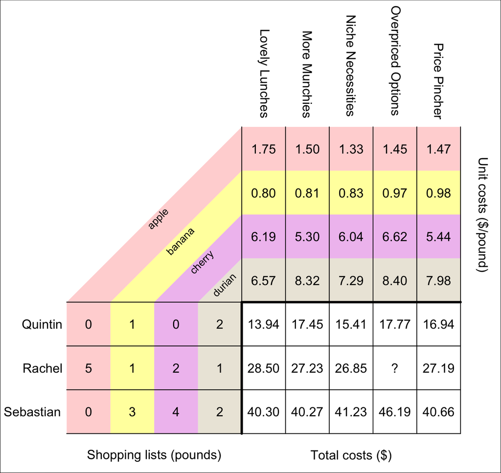

What is the total cost of Rachel shopping at Overpriced Options?

Rachel wishes to buy 5 lb of apple, 1 lb of banana, 2 lb of cherry, and 1 lb of durian. At Overpriced Options, the unit price of apple is $1.45/lb, the unit price of banana is $0.97/lb, the unit price of cherry is $6.62/lb, and the unit price of durian is $8.40/lb.

To find the total cost of Rachel's shopping trip, multiply each quantity by its corresponding unit price and then add up all those products.

$$(5\cdot1.45)~+~(1\cdot0.97)~+~(2\cdot6.62)~+~(1\cdot8.4)$$
$$7.25~+~0.97~+~13.24~+~8.4$$
$$29.86$$

So, the total cost of Rachel shopping at Overpriced Options is $29.86.

In standard math notation, the matrix multiplication would be shown as:

$$\begin{bmatrix}
0 & 1 & 0 & 2\\
5 & 1 & 2 & 1\\
0 & 3 & 4 & 2
\end{bmatrix} \cdot \begin{bmatrix}
1.75 & 1.5 & 1.33 & 1.45 & 1.47\\
0.8 & 0.81 & 0.83 & 0.97 & 0.98\\
6.19 & 5.3 & 6.04 & 6.62 & 5.44\\
6.57 & 8.32 & 7.29 & 8.4 & 7.98
\end{bmatrix} ~=~ \begin{bmatrix}
13.94 & 17.45 & 15.41 & 17.77 & 16.94\\
28.5 & 27.23 & 26.85 & 29.86 & 27.19\\
40.3 & 40.27 & 41.23 & 46.19 & 40.66
\end{bmatrix}$$

Let matrices $A$ and $B$ be defined below.

$$A = \begin{bmatrix}
2 & 6 & 5 & 4\\
6 & 2 & 5 & 1\\
5 & 0 & 6 & 0
\end{bmatrix}$$
$$B = \begin{bmatrix}
5 & 5 & 1 & 0 & 3\\
6 & 0 & 1 & 4 & 2\\
3 & 1 & 1 & 3 & 1\\
3 & 5 & 0 & 4 & 1
\end{bmatrix}$$

A third matrix, $C$, is equal to the [product](https://en.wikipedia.org/wiki/Matrix_multiplication) $AB$. A student set up a diagram to help find the product; they are missing a single element in $C$, element $c_{2,1}$.

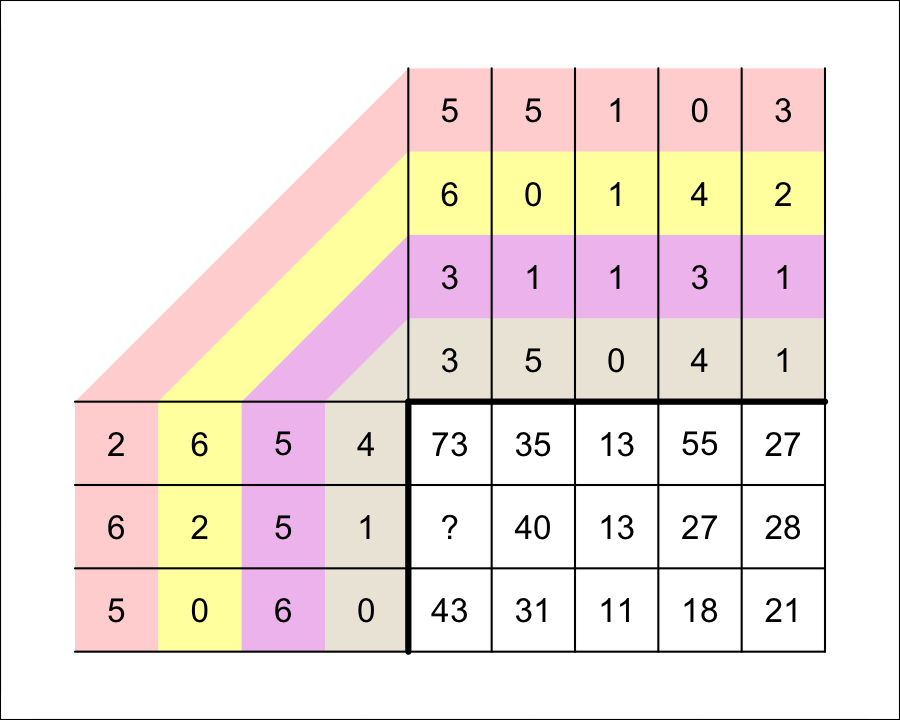

What is $c_{2,1}$?

To find $c_{2,1}$, you use row 2 from matrix $A$ and column 1 from matrix $B$.

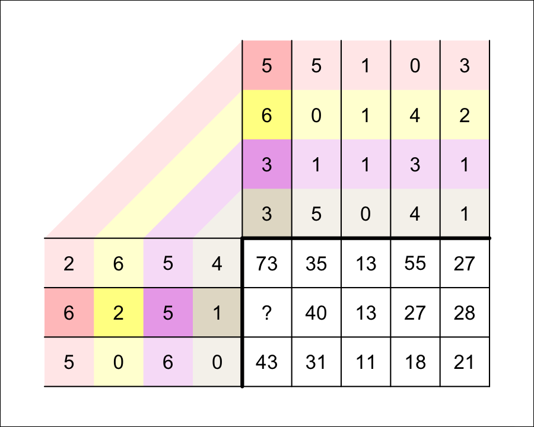

You multiply corresponding elements and sum those products.

$$c_{2,1}~=~( 6 \cdot 5 )+( 2 \cdot 6
)+( 5 \cdot 3 )+( 1 \cdot 3 )$$

$$c_{2,1}~=~30+12+15+3$$

$$c_{2,1}~=~60$$

Thus,

$$\begin{bmatrix}
2 & 6 & 5 & 4\\
6 & 2 & 5 & 1\\
5 & 0 & 6 & 0
\end{bmatrix} \cdot \begin{bmatrix}
5 & 5 & 1 & 0 & 3\\
6 & 0 & 1 & 4 & 2\\
3 & 1 & 1 & 3 & 1\\
3 & 5 & 0 & 4 & 1
\end{bmatrix} ~=~ \begin{bmatrix}
73 & 35 & 13 & 55 & 27\\
60 & 40 & 13 & 27 & 28\\
43 & 31 & 11 & 18 & 21
\end{bmatrix}$$

Let matrices $A$ and $B$ be defined below.

$$A = \begin{bmatrix}
3 & 5 & 0 & 4\\
2 & 3 & 0 & 0\\
2 & 3 & 6 & 3
\end{bmatrix}$$
$$B = \begin{bmatrix}
3 & 2 & 5 & 0 & 6\\
2 & 1 & 4 & 6 & 0\\
0 & 5 & 0 & 5 & 0\\
5 & 1 & 6 & 2 & 1
\end{bmatrix}$$

A third matrix, $C$, is equal to the [product](https://en.wikipedia.org/wiki/Matrix_multiplication) $AB$. A student set up a diagram to help find the product; they are missing a single element in $C$, element $c_{1,4}$.

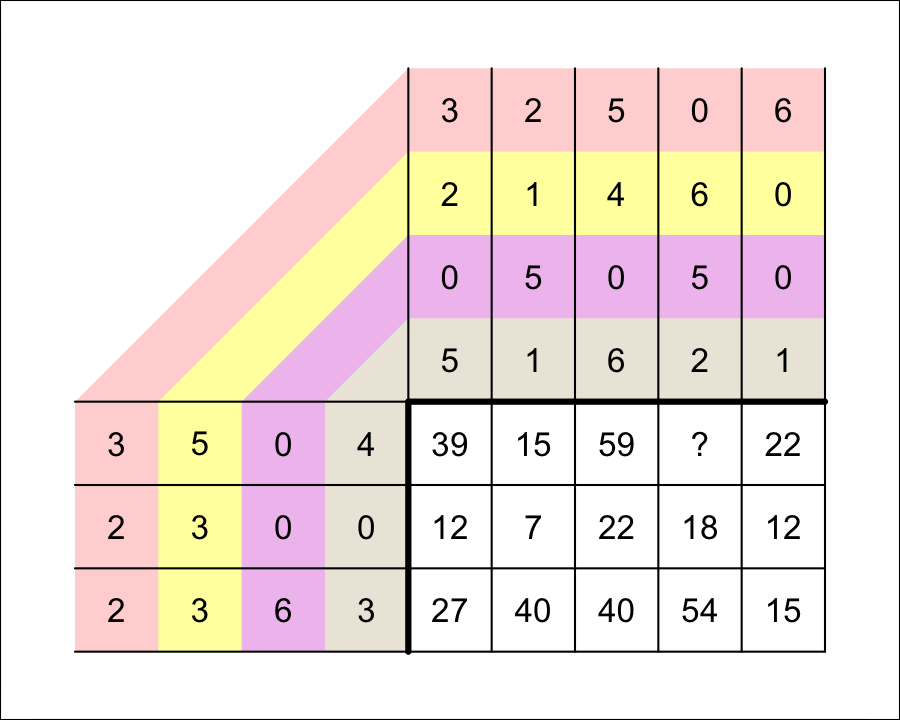

What is $c_{1,4}$?

To find $c_{1,4}$, you use row 1 from matrix $A$ and column 4 from matrix $B$.

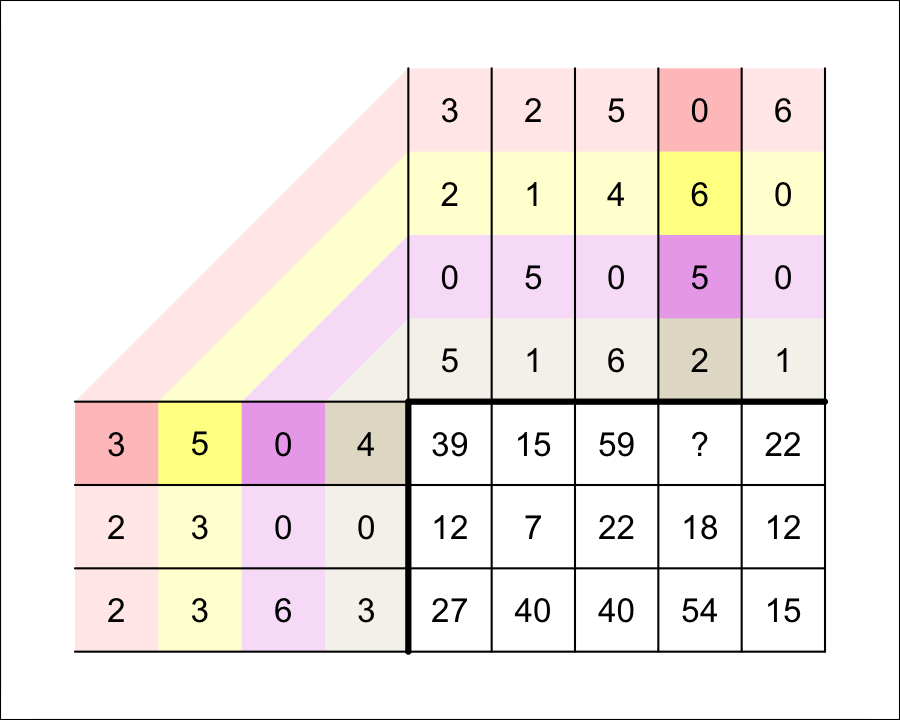

You multiply corresponding elements and sum those products.

$$c_{1,4}~=~( 3 \cdot 0 )+( 5 \cdot 6
)+( 0 \cdot 5 )+( 4 \cdot 2 )$$

$$c_{1,4}~=~0+30+0+8$$

$$c_{1,4}~=~38$$

Thus,

$$\begin{bmatrix}
3 & 5 & 0 & 4\\
2 & 3 & 0 & 0\\
2 & 3 & 6 & 3
\end{bmatrix} \cdot \begin{bmatrix}
3 & 2 & 5 & 0 & 6\\
2 & 1 & 4 & 6 & 0\\
0 & 5 & 0 & 5 & 0\\
5 & 1 & 6 & 2 & 1
\end{bmatrix} ~=~ \begin{bmatrix}
39 & 15 & 59 & 38 & 22\\
12 & 7 & 22 & 18 & 12\\
27 & 40 & 40 & 54 & 15
\end{bmatrix}$$

Let matrices $A$ and $B$ be defined below.

$$A = \begin{bmatrix}
3 & 5 & 5 & 0\\
0 & 0 & 1 & 5\\
5 & 5 & 4 & 5
\end{bmatrix}$$
$$B = \begin{bmatrix}
5 & 3 & 4 & 2 & 3\\
5 & 0 & 4 & 3 & 0\\
2 & 4 & 1 & 2 & 3\\
2 & 1 & 5 & 0 & 1
\end{bmatrix}$$

A third matrix, $C$, is equal to the [product](https://en.wikipedia.org/wiki/Matrix_multiplication) $AB$. A student set up a diagram to help find the product; they are missing a single element in $C$, element $c_{2,5}$.

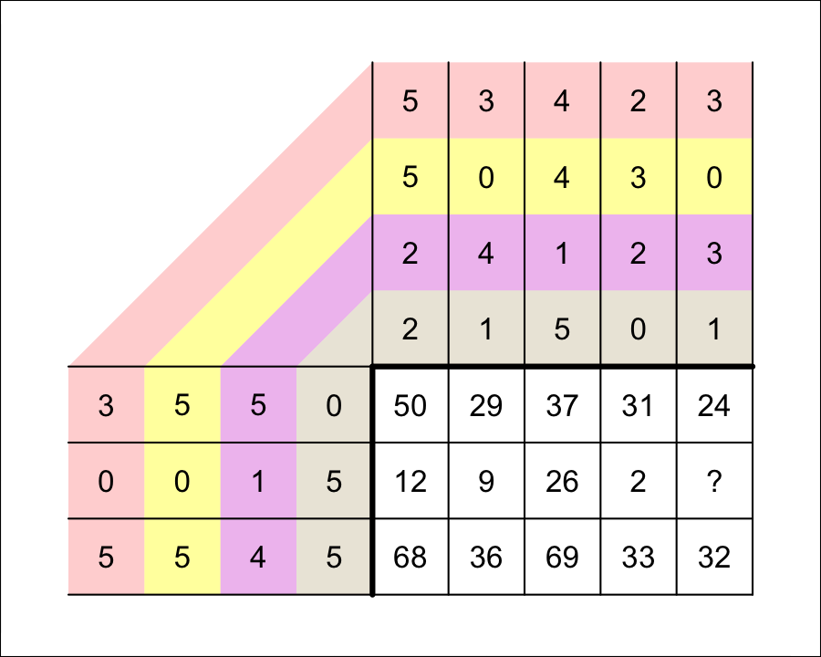

What is $c_{2,5}$?

To find $c_{2,5}$, you use row 2 from matrix $A$ and column 5 from matrix $B$.

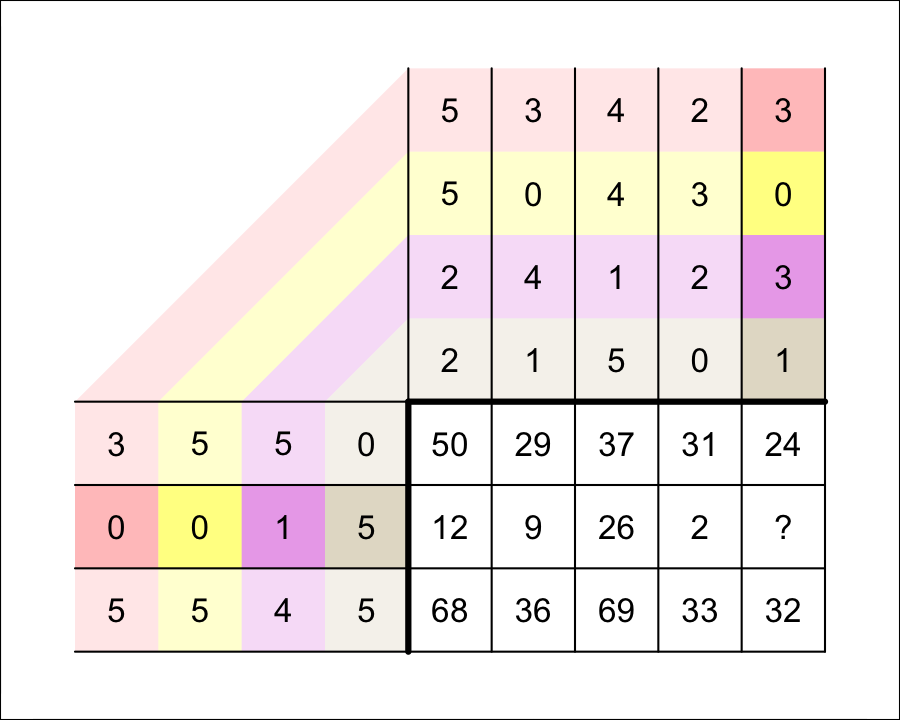

You multiply corresponding elements and sum those products.

$$c_{2,5}~=~( 0 \cdot 3 )+( 0 \cdot 0
)+( 1 \cdot 3 )+( 5 \cdot 1 )$$

$$c_{2,5}~=~0+0+3+5$$

$$c_{2,5}~=~8$$

Thus,

$$\begin{bmatrix}
3 & 5 & 5 & 0\\
0 & 0 & 1 & 5\\
5 & 5 & 4 & 5
\end{bmatrix} \cdot \begin{bmatrix}
5 & 3 & 4 & 2 & 3\\
5 & 0 & 4 & 3 & 0\\
2 & 4 & 1 & 2 & 3\\
2 & 1 & 5 & 0 & 1
\end{bmatrix} ~=~ \begin{bmatrix}
50 & 29 & 37 & 31 & 24\\
12 & 9 & 26 & 2 & 8\\
68 & 36 & 69 & 33 & 32
\end{bmatrix}$$

Let matrices $A$ and $B$ be defined below.

$$A = \begin{bmatrix}
1 & 6 & 4 & 1\\
2 & 4 & 1 & 2\\
5 & 2 & 1 & 4
\end{bmatrix}$$
$$B = \begin{bmatrix}
0 & 4 & 5 & 3 & 1\\
0 & 0 & 3 & 4 & 5\\
2 & 2 & 1 & 2 & 3\\
2 & 4 & 4 & 1 & 0
\end{bmatrix}$$

A third matrix, $C$, is equal to the [product](https://en.wikipedia.org/wiki/Matrix_multiplication) $AB$. A student set up a diagram to help find the product; they are missing a single element in $C$, element $c_{1,2}$.

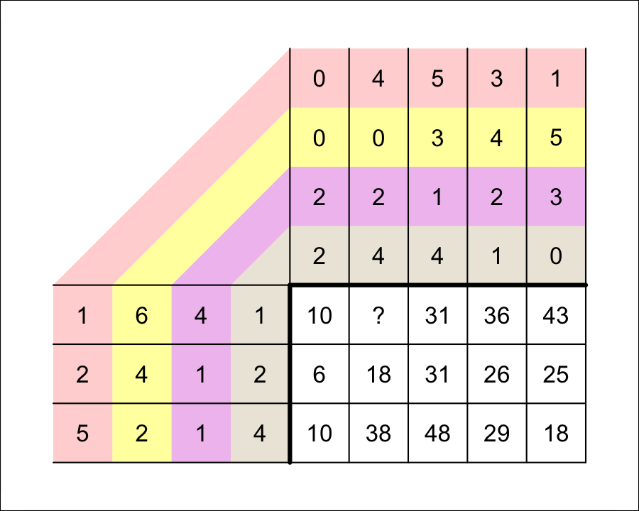

What is $c_{1,2}$?

To find $c_{1,2}$, you use row 1 from matrix $A$ and column 2 from matrix $B$.

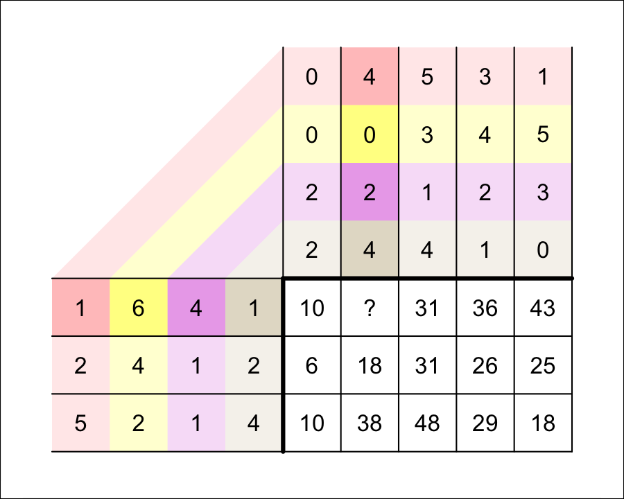

You multiply corresponding elements and sum those products.

$$c_{1,2}~=~( 1 \cdot 4 )+( 6 \cdot 0
)+( 4 \cdot 2 )+( 1 \cdot 4 )$$

$$c_{1,2}~=~4+0+8+4$$

$$c_{1,2}~=~16$$

Thus,

$$\begin{bmatrix}
1 & 6 & 4 & 1\\
2 & 4 & 1 & 2\\
5 & 2 & 1 & 4
\end{bmatrix} \cdot \begin{bmatrix}
0 & 4 & 5 & 3 & 1\\
0 & 0 & 3 & 4 & 5\\
2 & 2 & 1 & 2 & 3\\
2 & 4 & 4 & 1 & 0
\end{bmatrix} ~=~ \begin{bmatrix}
10 & 16 & 31 & 36 & 43\\
6 & 18 & 31 & 26 & 25\\
10 & 38 & 48 & 29 & 18
\end{bmatrix}$$

Let matrices $A$ and $B$ be defined below.

$$A = \begin{bmatrix}
3 & 3 & 1 & 6\\
2 & 4 & 4 & 4\\
3 & 1 & 5 & 4
\end{bmatrix}$$
$$B = \begin{bmatrix}
0 & 6 & 2 & 3 & 3\\
0 & 2 & 0 & 0 & 0\\
3 & 2 & 2 & 1 & 5\\
0 & 3 & 4 & 5 & 3
\end{bmatrix}$$

A third matrix, $C$, is equal to the [product](https://en.wikipedia.org/wiki/Matrix_multiplication) $AB$. A student set up a diagram to help find the product; they are missing a single element in $C$, element $c_{3,4}$.

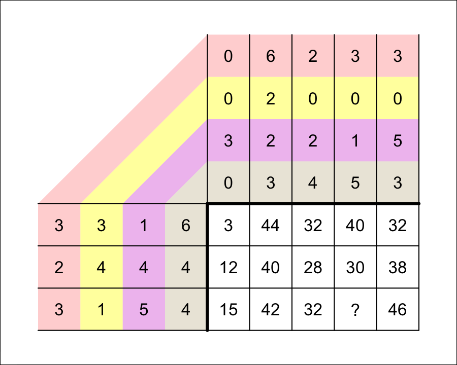

What is $c_{3,4}$?

To find $c_{3,4}$, you use row 3 from matrix $A$ and column 4 from matrix $B$.

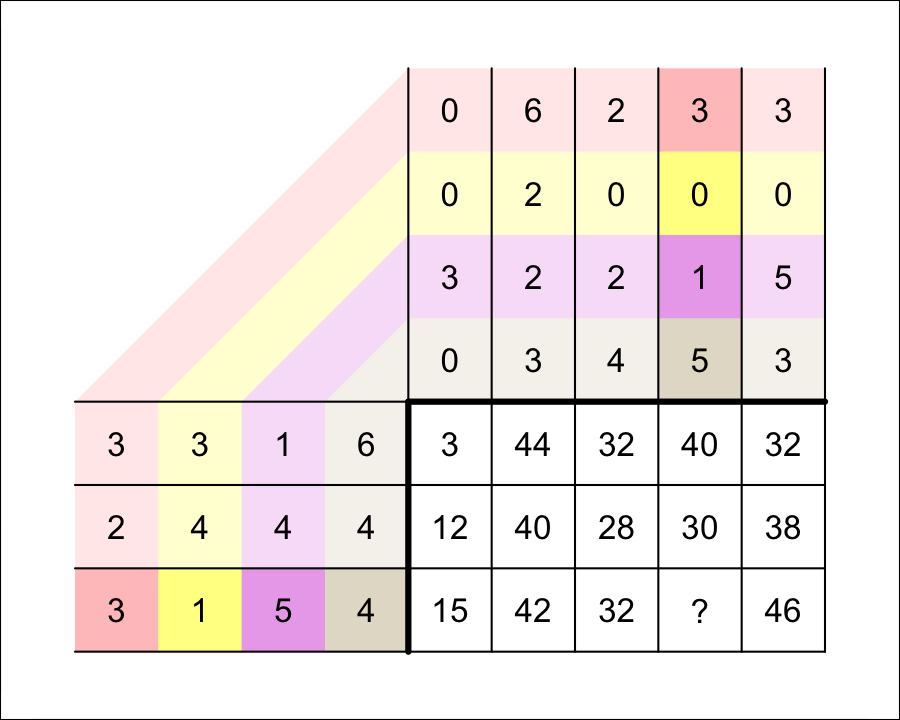